# Exercise

```python
# Import the libraries
import pandas as pd
import numpy as np
```

```python
# Load the dataset and show some data
df_loan = pd.read_excel('./data loan.xlsx')
print(df_loan.shape)
display(df_loan.head())
display(df_loan.tail())
```

```
(28293, 23)
```

|  | Kontrak | Tipe_Kendaraan | Pekerjaan | Area | Tenor | Bucket_Collectability | NPF | Total_AR | LTV | OTR | ... | DP | AF | Tujuan | Pendidikan | Tanggungan | Status | Gender | Paket | Inflasi | Segmen |
| --- | --- | --- | --- | --- | --- | --- | --- | --- | --- | --- | --- | --- | --- | --- | --- | --- | --- | --- | --- | --- | --- |
| 0 | 1 | OTHERS | Karyawan | Jawa | 12 | >90 - 120 hari | Ya | 2.763126 | 100.00 | 2.76 | ... | 0.0 | 2.76 | Private | Sarjana | Tidak ada | OTHERS | Laki-laki | Ya | 3.58 | Jasa & Perdagangan |
| 1 | 2 | OTHERS | Wiraswasta | Jawa | 12 | 0 - 30 hari | Tidak | 2.805000 | 103.70 | 2.71 | ... | 0.0 | 2.81 | Private | Others | Tidak ada | MENIKAH | Laki-laki | Ya | 3.58 | Others |
| 2 | 3 | OTHERS | Wiraswasta | Jawa | 12 | 0 - 30 hari | Tidak | 3.104000 | 103.33 | 3.00 | ... | 0.0 | 3.10 | Private | Sarjana | Tidak ada | OTHERS | Perempuan | Ya | 4.17 | Others |
| 3 | 4 | OTHERS | Karyawan | Jawa | 12 | 0 - 30 hari | Tidak | 4.088100 | 102.51 | 3.98 | ... | 0.0 | 4.08 | Private | Sarjana | Ada | OTHERS | Laki-laki | Ya | 3.61 | Jasa & Perdagangan |
| 4 | 5 | OTHERS | Karyawan | Jawa | 12 | 0 - 30 hari | Tidak | 4.607100 | 102.22 | 4.50 | ... | 0.0 | 4.60 | Private | Sarjana | Tidak ada | OTHERS | Perempuan | Ya | 3.30 | Jasa & Perdagangan |

5 rows × 23 columns

|  | Kontrak | Tipe_Kendaraan | Pekerjaan | Area | Tenor | Bucket_Collectability | NPF | Total_AR | LTV | OTR | ... | DP | AF | Tujuan | Pendidikan | Tanggungan | Status | Gender | Paket | Inflasi | Segmen |
| --- | --- | --- | --- | --- | --- | --- | --- | --- | --- | --- | --- | --- | --- | --- | --- | --- | --- | --- | --- | --- | --- |
| 28288 | 28289 | MINIBUS | Wiraswasta | Sumatera | 60 | > 150 hari | Ya | 468.719995 | 90.34 | 347.50 | ... | 69.50 | 313.95 | Private | Sarjana | Tidak ada | OTHERS | Laki-laki | Ya | 3.61 | Jasa & Perdagangan |
| 28289 | 28290 | MINIBUS | Wiraswasta | Sumatera | 60 | > 150 hari | Ya | 435.840003 | 92.16 | 304.00 | ... | 60.80 | 280.16 | Private | Others | Tidak ada | MENIKAH | Perempuan | Tidak | 3.61 | Jasa & Perdagangan |
| 28290 | 28291 | MINIBUS | Karyawan | Sumatera | 60 | >120 - 150 hari | Ya | 536.339999 | 87.01 | 432.00 | ... | 108.00 | 375.86 | Private | Sarjana | Ada | OTHERS | Perempuan | Ya | 3.61 | Others |
| 28291 | 28292 | MINIBUS | Wiraswasta | Sumatera | 60 | > 150 hari | Ya | 584.880008 | 92.34 | 407.30 | ... | 81.46 | 376.10 | Private | Others | Tidak ada | MENIKAH | Laki-laki | Tidak | 3.61 | Jasa & Perdagangan |
| 28292 | 28293 | OTHERS | Wiraswasta | Jawa | 60 | > 150 hari | Ya | 670.020007 | 89.59 | 515.74 | ... | 103.17 | 462.05 | Private | Others | Ada | MENIKAH | Perempuan | Tidak | 3.61 | Jasa & Perdagangan |

5 rows × 23 columns

- Kontrak : nomor kontrak
- Tipe_Kendaraan : tipe kendaraan yang dibeli
- Pekerjaan : jenis pekerjaan
- Area : area kantor tempat kredit diberikan
- Tenor : jangka waktu hutang yang diajukan (bulan)
- Bucket_Collectability : keterlambatan membayar hutang (hari)
- NPF : non performing financing
- Total_AR : jumlah pinjaman yang diterima (juta rupiah)
- LTV : loan to value (%)
- OTR : harga beli mobil setelah ditambahkan dengan seluruh pajak dan berbagai dokumen lainnya (puluh juta rupiah)
- Age : usia (tahun)
- Interest_Rate : suku bunga bank indonesia (%)
- Income : pendapatan (juta rupiah)
- DP : uang muka (juta rupiah)
- AF : amount financed (juta rupiah)
- Tujuan : tujuan pembelian
- Pendidikan : tingkat pendidikan
- Tanggungan : jumlah tanggungan keluarga
- Status : status pernikahan peminjam
- Gender : gender peminjam
- Paket : paket kredit
- Inflasi : tingkat inflasi (%)
- Segmen : segmentasi transaksi

**1. Ambil sampel secara acak dari data loan sebanyak 80% dari banyaknya data.**

```python
df_loan_80 = df_loan.sample(frac=0.8)
print(df_loan_80.shape)
display(df_loan_80.head())
```

```
(22634, 23)
```

|  | Kontrak | Tipe_Kendaraan | Pekerjaan | Area | Tenor | Bucket_Collectability | NPF | Total_AR | LTV | OTR | ... | DP | AF | Tujuan | Pendidikan | Tanggungan | Status | Gender | Paket | Inflasi | Segmen |
| --- | --- | --- | --- | --- | --- | --- | --- | --- | --- | --- | --- | --- | --- | --- | --- | --- | --- | --- | --- | --- | --- |
| 7862 | 7863 | LCGC | Wiraswasta | Jawa | 36 | > 150 hari | Ya | 119.365710 | 81.90 | 120.75 | ... | 30.19 | 98.89 | Private | Others | Tidak ada | OTHERS | Laki-laki | Ya | 8.22 | Others |
| 13553 | 13554 | MINIBUS | Karyawan | Jawa | 48 | 0 - 30 hari | Tidak | 175.167799 | 80.38 | 174.45 | ... | 55.15 | 140.22 | Private | Sarjana | Tidak ada | MENIKAH | Laki-laki | Tidak | 7.75 | Others |
| 14661 | 14662 | LCGC | Karyawan | Jawa | 60 | >30 - 90 hari | Tidak | 183.900003 | 96.83 | 118.25 | ... | 23.65 | 114.50 | Private | Others | Ada | OTHERS | Laki-laki | Ya | 3.33 | Others |
| 2027 | 2028 | MINIBUS | Karyawan | Jawa | 36 | 0 - 30 hari | Tidak | 176.111998 | 69.98 | 216.00 | ... | 80.92 | 151.15 | Private | Others | Tidak ada | OTHERS | Perempuan | Tidak | 3.35 | Others |
| 10756 | 10757 | LCGC | Karyawan | Sumatera | 48 | > 150 hari | Ya | 151.632000 | 90.10 | 119.70 | ... | 29.93 | 107.85 | Private | Others | Ada | OTHERS | Perempuan | Ya | 7.26 | Jasa & Perdagangan |

5 rows × 23 columns

```python
# Check the data info
df_loan_80.info()
```

```
<class 'pandas.core.frame.DataFrame'>
Int64Index: 22634 entries, 7862 to 10549
Data columns (total 23 columns):
Kontrak                  22634 non-null int64
Tipe_Kendaraan           22634 non-null object
Pekerjaan                22634 non-null object
Area                     22634 non-null object
Tenor                    22634 non-null int64
Bucket_Collectability    22634 non-null object
NPF                      22634 non-null object
Total_AR                 22634 non-null float64
LTV                      22634 non-null float64
OTR                      22634 non-null float64
Age                      22634 non-null int64
Interest_Rate            22634 non-null float64
Income                   22634 non-null int64
DP                       22634 non-null float64
AF                       22634 non-null float64
Tujuan                   22634 non-null object
Pendidikan               22634 non-null object
Tanggungan               22634 non-null object
Status                   22634 non-null object
Gender                   22634 non-null object
Paket                    22634 non-null object
Inflasi                  22634 non-null float64
Segmen                   22634 non-null object
dtypes: float64(7), int64(4), object(12)
memory usage: 4.1+ MB
```

```python
# Check any missing value from the data
df_loan_80.isnull().sum()
```

```
Kontrak                  0
Tipe_Kendaraan           0
Pekerjaan                0
Area                     0
Tenor                    0
Bucket_Collectability    0
NPF                      0
Total_AR                 0
LTV                      0
OTR                      0
Age                      0
Interest_Rate            0
Income                   0
DP                       0
AF                       0
Tujuan                   0
Pendidikan               0
Tanggungan               0
Status                   0
Gender                   0
Paket                    0
Inflasi                  0
Segmen                   0
dtype: int64
```

No missing value, good sign

```python
# Show the value counts of the datatypes
df_loan_80.dtypes.value_counts()
```

```
object     12
float64     7
int64       4
dtype: int64
```

```python
# Show how many categories for each object columns
df_loan_80.select_dtypes('object').apply(pd.Series.nunique, axis = 0)
```

```
Tipe_Kendaraan           4
Pekerjaan                3
Area                     3
Bucket_Collectability    5
NPF                      2
Tujuan                   2
Pendidikan               2
Tanggungan               2
Status                   2
Gender                   2
Paket                    2
Segmen                   2
dtype: int64
```

```python
# Encoding categorical variables
# Create a label encoder object
from sklearn.preprocessing import LabelEncoder
le = LabelEncoder()
le_count = 0

# Iterate through the columns
for col in df_loan_80:
    if df_loan_80[col].dtype == 'object':
        # If 2 or fewer unique categories
        if len(list(df_loan_80[col].unique())) <= 2:
            # Train on the training data
            le.fit(df_loan_80[col])
            # Transform both training and testing data
            df_loan_80[col] = le.transform(df_loan_80[col])

            # Keep track of how many columns were label encoded
            le_count += 1

print('{} columns were label encoded.'.format(le_count))
```

[output not shown]

```python
# one-hot encoding of categorical variables
df_loan_80 = pd.get_dummies(df_loan_80)

print('data shape: ', df_loan_80.shape)
```

```
data shape:  (22634, 34)
```

```python
# Check if there is any outliers
for col in df_loan_80.columns[:19]:
    display(df_loan_80[col].describe())
```

```
count    22634.000000
mean     14181.384289
std       8172.863352
min          1.000000
25%       7120.500000
50%      14189.500000
75%      21261.750000
max      28293.000000
Name: Kontrak, dtype: float64
```

```
count    22634.000000
mean        45.117964
std         13.271745
min         12.000000
25%         36.000000
50%         48.000000
75%         60.000000
max         60.000000
Name: Tenor, dtype: float64
```

```
count    22634.000000
mean         0.494080
std          0.499976
min          0.000000
25%          0.000000
50%          0.000000
75%          1.000000
max          1.000000
Name: NPF, dtype: float64
```

```
count    22634.000000
mean       214.946865
std         88.321269
min          1.803600
25%        156.199020
50%        201.373468
75%        266.496000
max       1854.341300
Name: Total_AR, dtype: float64
```

```
count    22634.000000
mean        81.160968
std         14.938956
min          5.110000
25%         77.870000
50%         83.850000
75%         89.347500
max        111.830000
Name: LTV, dtype: float64
```

```
count    22634.000000
mean       204.457447
std         79.792604
min          1.690000
25%        157.950000
50%        187.800000
75%        231.200000
max       1508.400000
Name: OTR, dtype: float64
```

```
count    22634.000000
mean        40.654370
std          9.580267
min         19.000000
25%         34.000000
50%         40.000000
75%         47.000000
max         82.000000
Name: Age, dtype: float64
```

```
count    22634.000000
mean        13.739359
std          3.524860
min          0.000000
25%         11.190000
50%         13.450000
75%         16.210000
max         27.400000
Name: Interest_Rate, dtype: float64
```

```
count    22634.000000
mean        19.503181
std         75.953808
min          1.000000
25%          9.000000
50%         15.000000
75%         20.000000
max      10000.000000
Name: Income, dtype: float64
```

```
count    22634.000000
mean        59.101817
std         40.749186
min          0.000000
25%         37.790000
50%         47.705000
75%         67.750000
max        721.350000
Name: DP, dtype: float64
```

```
count    22634.000000
mean       163.665990
std         64.105168
min          1.790000
25%        122.630000
50%        153.405000
75%        193.657500
max       1312.810000
Name: AF, dtype: float64
```

```
count    22634.000000
mean         0.879297
std          0.325789
min          0.000000
25%          1.000000
50%          1.000000
75%          1.000000
max          1.000000
Name: Tujuan, dtype: float64
```

```
count    22634.000000
mean         0.433198
std          0.495528
min          0.000000
25%          0.000000
50%          0.000000
75%          1.000000
max          1.000000
Name: Pendidikan, dtype: float64
```

```
count    22634.000000
mean         0.555580
std          0.496912
min          0.000000
25%          0.000000
50%          1.000000
75%          1.000000
max          1.000000
Name: Tanggungan, dtype: float64
```

```
count    22634.000000
mean         0.502518
std          0.500005
min          0.000000
25%          0.000000
50%          1.000000
75%          1.000000
max          1.000000
Name: Status, dtype: float64
```

```
count    22634.000000
mean         0.259698
std          0.438478
min          0.000000
25%          0.000000
50%          0.000000
75%          1.000000
max          1.000000
Name: Gender, dtype: float64
```

```
count    22634.000000
mean         0.435451
std          0.495827
min          0.000000
25%          0.000000
50%          0.000000
75%          1.000000
max          1.000000
Name: Paket, dtype: float64
```

```
count    22634.000000
mean         5.537273
std          1.798595
min          3.210000
25%          3.830000
50%          5.310000
75%          7.250000
max          8.790000
Name: Inflasi, dtype: float64
```

```
count    22634.000000
mean         0.434081
std          0.495647
min          0.000000
25%          0.000000
50%          0.000000
75%          1.000000
max          1.000000
Name: Segmen, dtype: float64
```

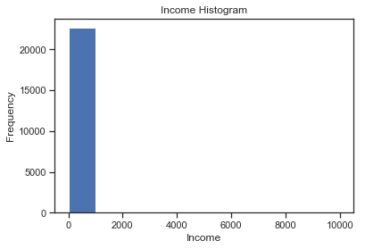

```python
# Check
df_loan_80['Income'].plot.hist(title = 'Income Histogram');
plt.xlabel('Income');
```

```python
# Check the outliers default rate
anom = df_loan_80[df_loan_80['Income'] < 2000]
non_anom = df_loan_80[df_loan_80['Income'] >= 2000]
print('The non-anomalies default on %0.2f%% of loans' % (100 * non_anom['NPF'].mean()))
print('The anomalies default on %0.2f%% of loans' % (100 * anom['NPF'].mean()))
print('There are %d anomalous income' % len(anom))
```

```
The non-anomalies default on 66.67% of loans
The anomalies default on 49.41% of loans
There are 22631 anomalous income
```

```python
# Find correlations with the target and sort
correlations = df_loan_80.corr()['NPF'].sort_values()

# Display correlations
print('Most Positive Correlations:\n', correlations.tail(10))
print('\nMost Negative Correlations:\n', correlations.head(10))
```

```
Most Positive Correlations:
 AF                                       0.176272
Kontrak                                  0.216685
Bucket_Collectability_>120 - 150 hari    0.222295
Total_AR                                 0.279751
Bucket_Collectability_>90 - 120 hari     0.280587
Tenor                                    0.321035
LTV                                      0.371456
Interest_Rate                            0.417378
Bucket_Collectability_> 150 hari         0.786578
NPF                                      1.000000
Name: NPF, dtype: float64

Most Negative Correlations:
 Bucket_Collectability_0 - 30 hari     -0.871115
Bucket_Collectability_>30 - 90 hari   -0.268317
DP                                    -0.251540
Age                                   -0.105081
Pendidikan                            -0.104051
Pekerjaan_Karyawan                    -0.096233
Tujuan                                -0.084949
Inflasi                               -0.067024
Area_Jawa                             -0.064224
Tipe_Kendaraan_MINIBUS                -0.048121
Name: NPF, dtype: float64
```

It looks like some features have negative relationship, lets take a look

```python
# Bin the age data to see the npf for each bin
# Age information into a separate dataframe
age_data = df_loan_80[['NPF', 'Age']]

# Bin the age data
age_data['age_binned'] = pd.cut(age_data['Age'], bins = np.linspace(19, 82, num = 11))
age_data.head(10)
```

|  | NPF | Age | age_binned |
| --- | --- | --- | --- |
| 7862 | 1 | 46 | (44.2, 50.5] |
| 13553 | 0 | 38 | (37.9, 44.2] |
| 14661 | 0 | 27 | (25.3, 31.6] |
| 2027 | 0 | 50 | (44.2, 50.5] |
| 10756 | 1 | 29 | (25.3, 31.6] |
| 14862 | 0 | 23 | (19.0, 25.3] |
| 17754 | 1 | 37 | (31.6, 37.9] |
| 5332 | 0 | 25 | (19.0, 25.3] |
| 8153 | 1 | 38 | (37.9, 44.2] |
| 7037 | 0 | 55 | (50.5, 56.8] |

```python
# Group by the bin and calculate averages
age_groups  = age_data.groupby('age_binned').mean()
age_groups
```

| age_binned | NPF | Age |
| --- | --- | --- |
| (19.0, 25.3] | 0.548646 | 23.377131 |
| (25.3, 31.6] | 0.542648 | 28.832272 |
| (31.6, 37.9] | 0.541959 | 34.642700 |
| (37.9, 44.2] | 0.502014 | 40.932586 |
| (44.2, 50.5] | 0.452830 | 47.380126 |
| (50.5, 56.8] | 0.434646 | 53.168504 |
| (56.8, 63.1] | 0.362183 | 59.174036 |
| (63.1, 69.4] | 0.302632 | 65.611842 |
| (69.4, 75.7] | 0.193548 | 71.838710 |
| (75.7, 82.0] | 0.250000 | 79.000000 |

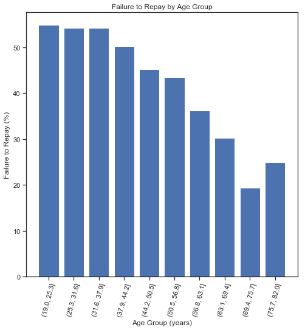

```python
plt.figure(figsize = (8, 8))

# Graph the age bins and the average of the target as a bar plot
plt.bar(age_groups.index.astype(str), 100 * age_groups['NPF'])

# Plot labeling
plt.xticks(rotation = 75); plt.xlabel('Age Group (years)'); plt.ylabel('Failure to Repay (%)')
plt.title('Failure to Repay by Age Group');
```

As we can see the data showed that the older customer tend to have good NPF

```python
from sklearn.preprocessing import MinMaxScaler, Imputer
from sklearn.model_selection import train_test_split

# Drop the target from the training data
# if 'NPF' in df_loan_80:
#     train = df_loan_80.drop(columns = ['NPF'])
# else:
#     train = df_loan_80.copy()

data_train = df_loan_80.copy()
data_train = data_train.drop(columns = ['NPF'])

X_train, X_test, y_train, y_test = train_test_split(data_train, df_loan_80['NPF'], test_size=0.3, random_state=42)

# Feature names
features = list(X_train.columns)

# Median imputation of missing values
imputer = Imputer(strategy = 'median')

# Scale each feature to 0-1
scaler = MinMaxScaler(feature_range = (0, 1))

# Fit on the training data
imputer.fit(X_train)

# Transform both training and testing data
train = imputer.transform(X_train)
test = imputer.transform(X_test)

# Repeat with the scaler
scaler.fit(train)
train = scaler.transform(train)
test = scaler.transform(test)

print('Training data shape: ', train.shape)
print('Testing data shape: ', test.shape)
```

```
Training data shape:  (15843, 33)
Testing data shape:  (6791, 33)
```

```python
from sklearn.linear_model import LogisticRegression

# Make the model with the specified regularization parameter
log_reg = LogisticRegression(C = 0.0001)

# Train on the training data
log_reg.fit(train, y_train)
```

```
LogisticRegression(C=0.0001, class_weight=None, dual=False,
          fit_intercept=True, intercept_scaling=1, max_iter=100,
          multi_class='warn', n_jobs=None, penalty='l2', random_state=None,
          solver='warn', tol=0.0001, verbose=0, warm_start=False)
```

```python
# Make predictions
# Make sure to select the second column only
log_reg_pred = log_reg.predict_proba(test)[:, 1]
```

```python
# Submission dataframe
submit = X_test[['Kontrak']]
submit['NPF'] = log_reg_pred

submit.head()
```

|  | Kontrak | NPF |
| --- | --- | --- |
| 5245 | 5246 | 0.567679 |
| 13869 | 13870 | 0.566453 |
| 7248 | 7249 | 0.413141 |
| 22320 | 22321 | 0.509704 |
| 27490 | 27491 | 0.446605 |

Above shown, are some example of score predicted by the model.